# Практикум по математической статистике.Осенний семестр. 4 курс, ВМК МГУ

Doynikov A

October 5, 2017

# Основные положения и требования к выполненю работы

Самостоятельная работа выполняется в виде кода на языке R, реализующего решение каждой задачи. Самостоятельная работа состоит из 5 задач. Для выполнения каждой из задач необходимо создать код на языке R выполнение которого позволяет решить конкретную задачу.Любой вывод должен быть статистически грамотно обоснован результатами выполнения соответствующего кода программы.

Защита самостоятельной работы состоит в представлении соответсвующих кодов программ, их выполнение и устного объяснения полученных результатов.

Не выполнение задачи под номером 5 (создание shiny приложения клиент- сервер) автоматически влечет снижение оценки на один балл.

Уровень значимости для всех критериев считаем равным 0.05.

Задание выдается до 1 декабря текущего года .

После 20 декабря, в согласованное со старостой группы время, проходит очная защита выполненной работы.

До 20 декабря, в согласованное со старостой группы время, возможна досрочная сдача работы с очной защитой или консультация по выполнению работы. В этот период найденные ошибки не влияют на оценку за работу, но подлежат обязательному исправлению. Оценка ставится только после исправления всех замечаний.

После 20 декабря ошибки приводят к снижению оценки за работу без возможности их исправления.

# Задачи самостоятельной работы.

## Вариант 1

### Задача1

Формулировка данной задачи одинакова для всех вариантов. Различны только статистические выборки.

Даны 4 выборки вида

```r
s <- read.csv("./var_1Task1.csv",header = TRUE)
head(s)
```

```
##            y        x1        x2        x3  X
## 1 -0.5670051 0.1028210 0.1081190 0.1950903 NA
## 2  1.0615354 0.2045521 0.2149704 0.3826834 NA
## 3  1.3425142 0.3041148 0.3193015 0.5555702 NA
## 4  1.8057731 0.4004539 0.4198891 0.7071068 NA
## 5  3.2784630 0.4925481 0.5155539 0.8314696 NA
## 6  2.3718904 0.5794211 0.6051742 0.9238795 NA
```

Оценить регрессионную модель
$$y_t=a_0+a_1x_1+a_2x_2+a_3x_3+a_4x_4+\epsilon_t$$
где распределение шума $\epsilon_t$ может быть одним из четырех распределений:

- равномерное на отрезке $[-u,u]$,
- нормальное $N(0,\sigma^2)$,
- Лапласа с параметрами $0,\mu$,
- t-распределение Стьюдента со среднем 0, дисперсией $\sigma^2$ или стандартным отклонием $\sigma$. Именно так задается это распределение в R, а не через более нам привычный параметр - число степеней свободы.

Исключить заведомо незначимые переменные (если такие найдутся), после чего переоценить модель только со значимыми переменными.

Исследовать остатки после удаления модели: определить тип распределения остатков (проверить соответствующие гипотезы и обосновать свой выбор, можно использовать тест Колмогорова-Смирнова,$\chi^2$ Пирсона или любой известный Вам другой), проверить некоррелируемость остатков.

## Указание к задаче 1.

### Вероятностные распределения

Здесь представлены методы, моделирования, выборочные гистограммы, проверка гипотезы о согласии с распределением (критерий Колмогорова-Смирнова). Как на R проверять гипотезу согласия по критерию $\chi^2$ Пирсона разберетесь сами. Чем больше критериев будет использовано при обосновании типа распределения, тем лучше.

Формулы для оценки параметров распределения по выборке найдете в википедии.

#### Распределение Нормальное

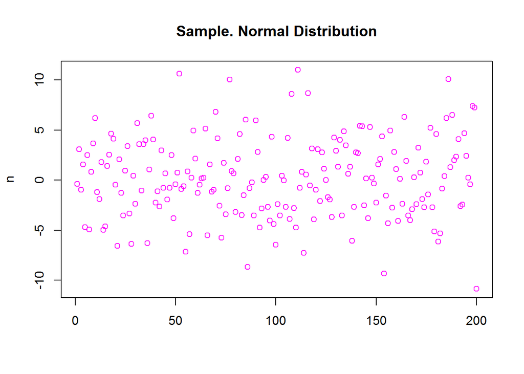

```r
n = rnorm(200,mean = 0,sd = 4)
matplot(n,type="p",pch=21,main = "Sample. Normal Distribution",col = "magenta")
```

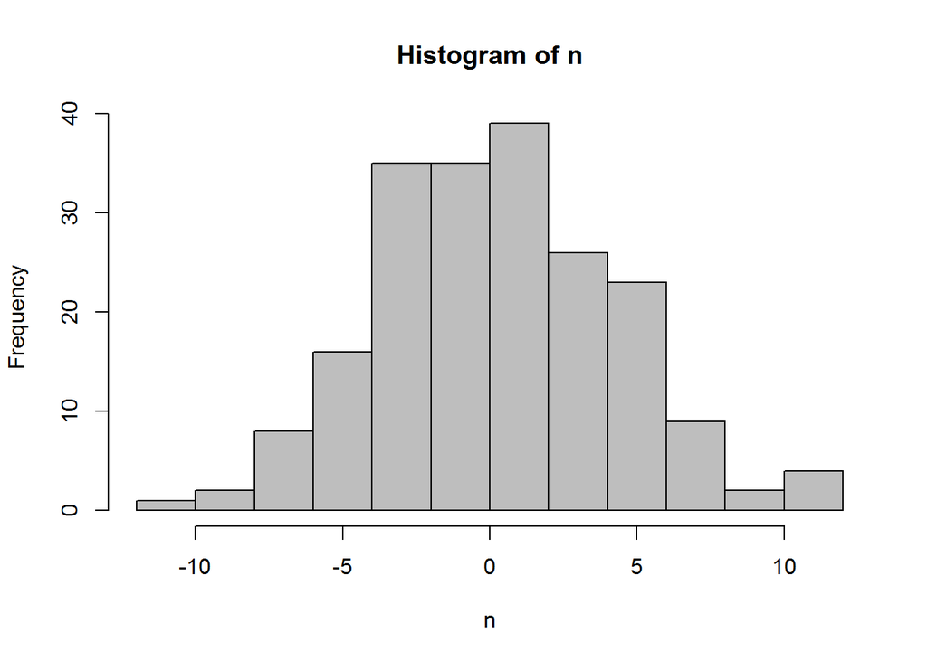

```r
hist(n,col = "grey")
```

```r
ks.test(n, "pnorm",0,4)
```

```
##
##  One-sample Kolmogorov-Smirnov test
##
## data:  n
## D = 0.035431, p-value = 0.9633
## alternative hypothesis: two-sided
```

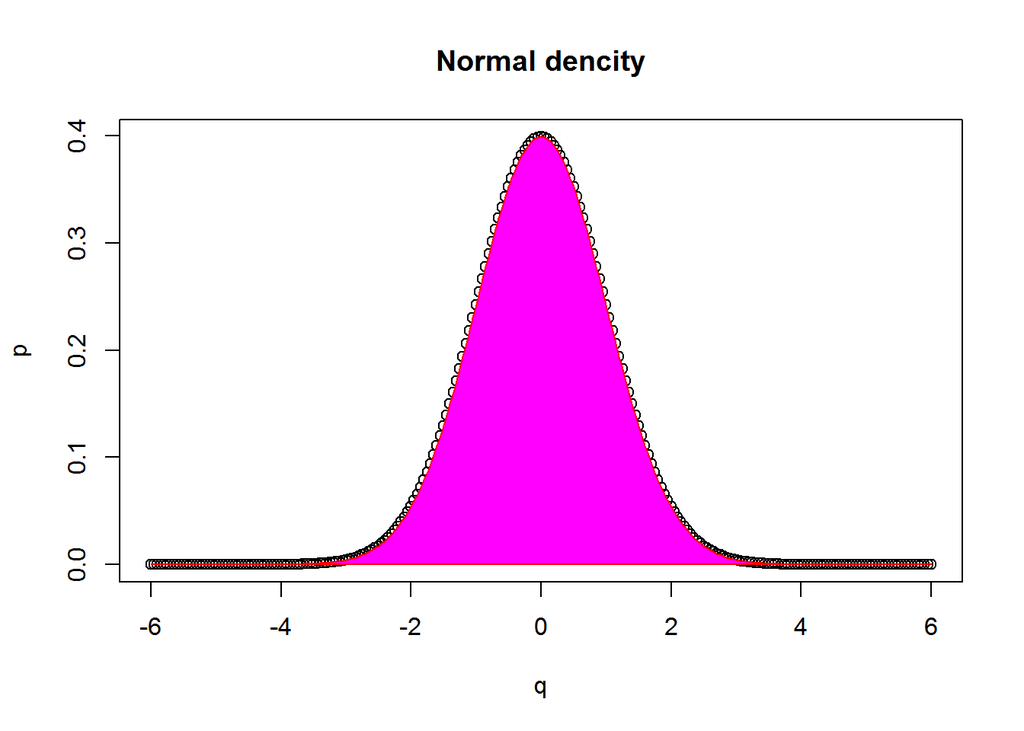

```r
q <- seq(from=-6, to=6, by=0.05)
p <- dnorm(q)
require(graphics)
plot(q,p, main = "Normal dencity")
polygon(q,p,xpd = FALSE, col = "magenta", lty = 1, lwd = 1, border = "red")
```

#### Распределение Равномерное на отрезке [a,b]

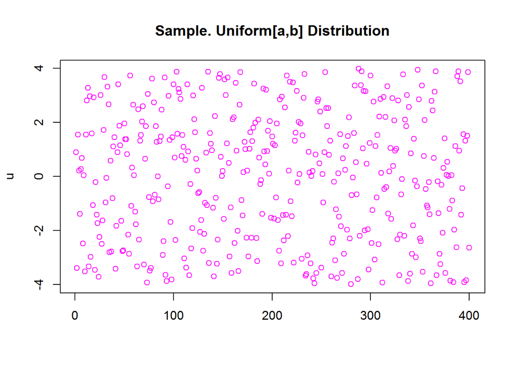

```r
u = runif(400,min = -4,max  = 4)
matplot(u,type="p",pch=21,main = "Sample. Uniform[a,b] Distribution",col = "magenta")
```

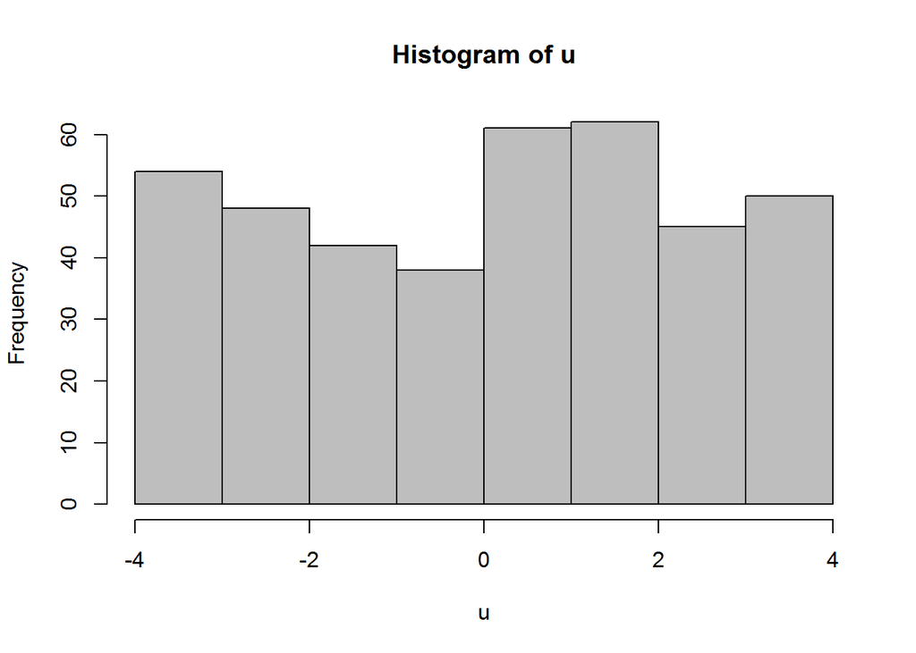

```r
hist(u,col = "grey")
```

```r
ks.test(u, "punif",-4,4)
```

```
##
##  One-sample Kolmogorov-Smirnov test
##
## data:  u
## D = 0.045571, p-value = 0.3772
## alternative hypothesis: two-sided
```

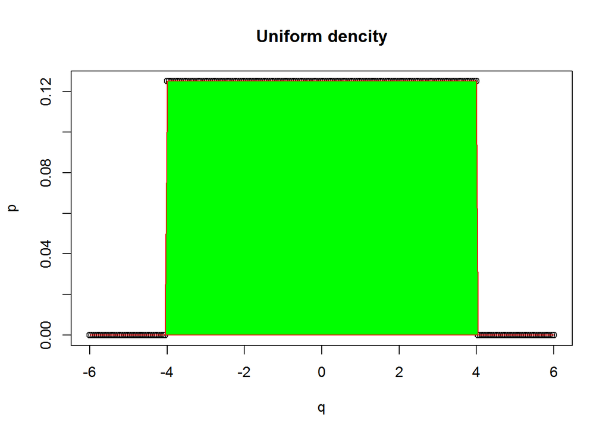

```r
p <- dunif(q,-4,4)
plot(q,p, main = "Uniform dencity")
polygon(q,p,xpd = FALSE, col = "green", lty = 1, lwd = 1, border = "red")
```

#### Распределение Лапласа

```r
library(LaplacesDemon)
```

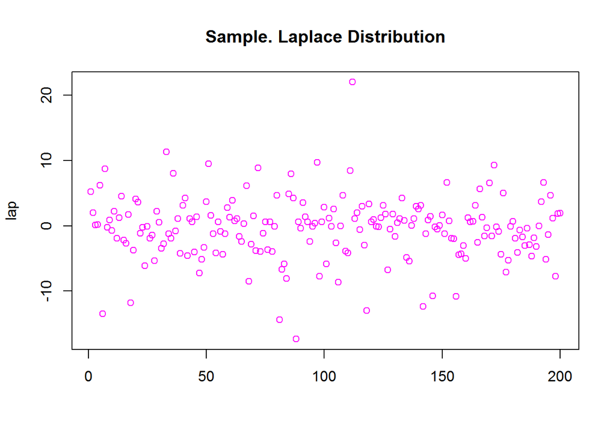

```r
lap = rlaplace(200,location = 0,scale = 4)
matplot(lap,type="p",pch=21,main = "Sample. Laplace Distribution",col = "magenta")
```

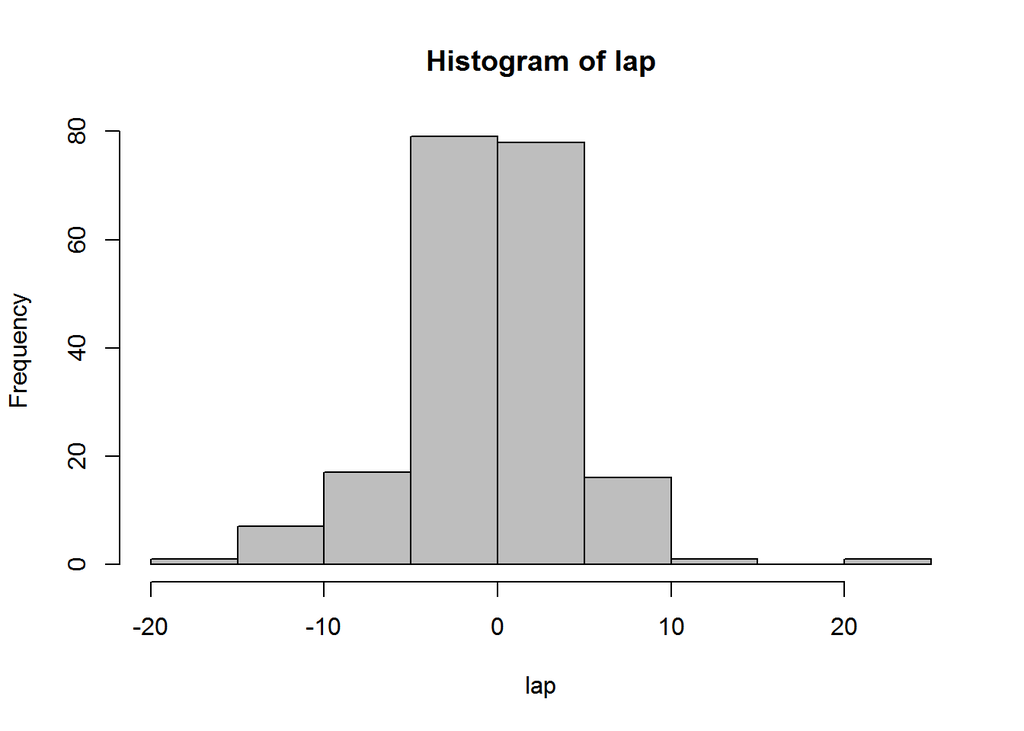

```r
hist(lap,col = "grey")
```

```r
ks.test(lap, "plaplace",0,4)
```

```
##
##  One-sample Kolmogorov-Smirnov test
##
## data:  lap
## D = 0.079152, p-value = 0.1631
## alternative hypothesis: two-sided
```

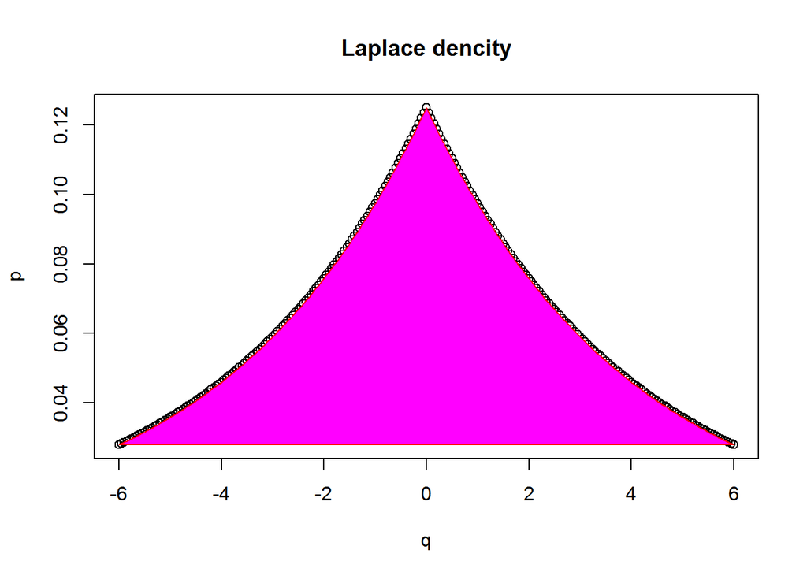

```r
p <- dlaplace(q,0,4)
plot(q,p, main = "Laplace dencity")
polygon(q,p,xpd = FALSE, col = "magenta", lty = 1, lwd = 1, border = "red")
```

#### t-Распределение Стюдента

```r
library(fGarch)
```

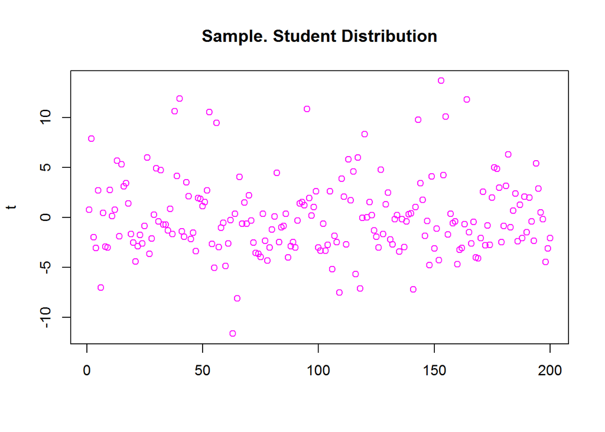

```r
t = rsstd(200,mean = 0,sd = 4)
matplot(t,type="p",pch=21,main = "Sample. Student Distribution",col = "magenta")
```

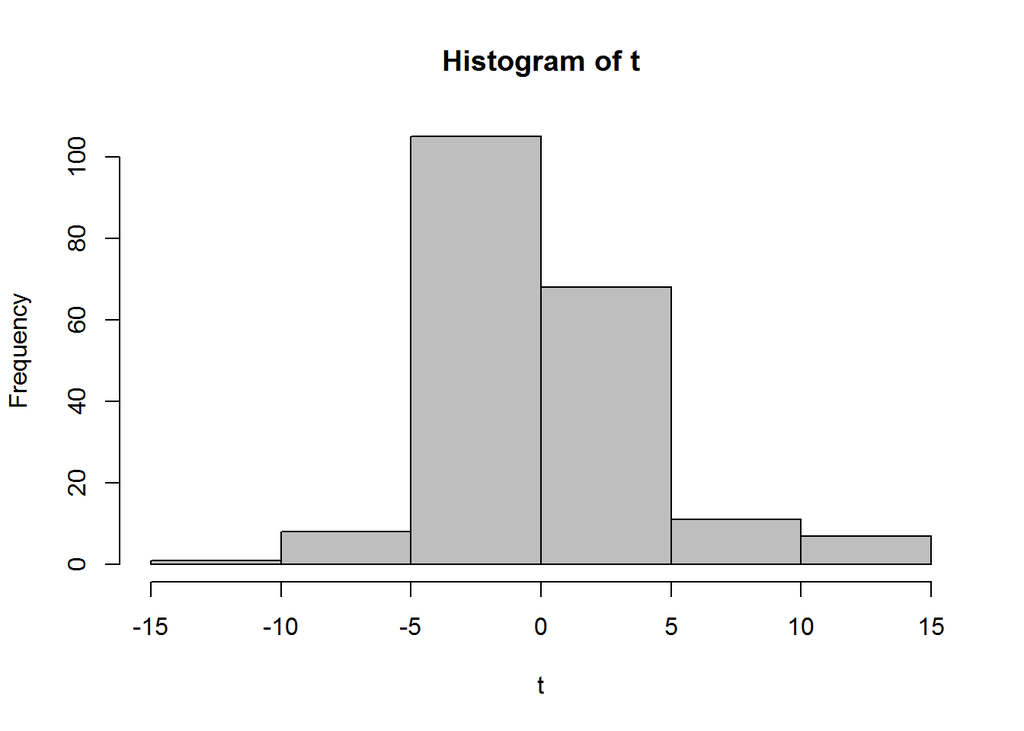

```r
hist(t,col = "grey")
```

```r
ks.test(t, "psstd",0,4)
```

```
##
##  One-sample Kolmogorov-Smirnov test
##
## data:  t
## D = 0.044551, p-value = 0.8222
## alternative hypothesis: two-sided
```

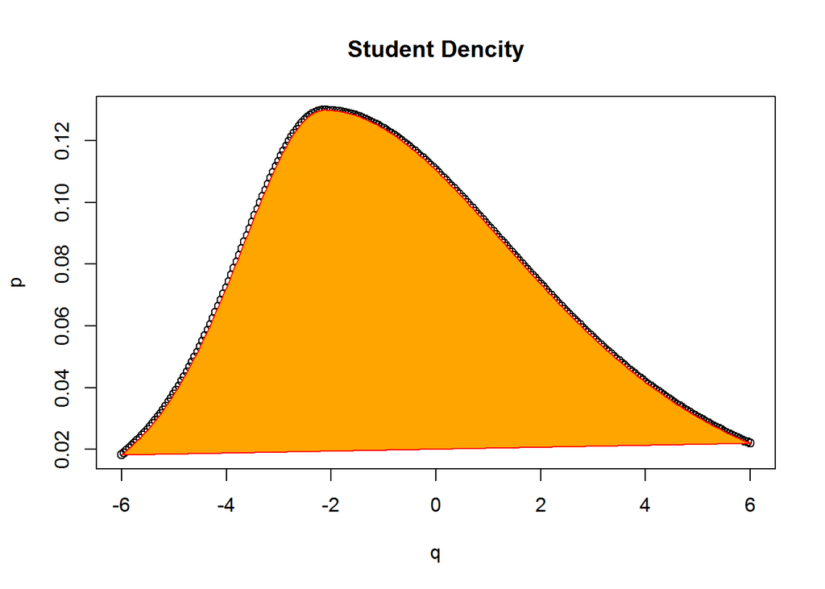

```r
p <- dsstd(q,0,4)
plot(q,p, main = "Student Dencity")
polygon(q,p,xpd = FALSE, col = "orange", lty = 1, lwd = 1, border = "red")
```

### Задача 2

Также звучит одинаково для всех вариантов. Разным является только данные по экономической статистике, которые студент импортирует с сайта http:/finam.ru/ и записывает в файл с расширением `*.csv`.

Импортировать макро экономическую статистику `EIA weekly crude stocks, USA` недельные данные за последние 5 лет. Адрес данных http://www.finam.ru/analysis/macroevent/?str=2&ind=770&timestep=1&dind=0. К полученным данным идентифицировать и оценить две различных, но обоснованно возможных ARMA модели. Выбрать из них наиболее адекватную (выбор Объяснить). Провести анализ остатков от удаления модели:тип вероятностного распределения,автокоррелированность остатков. Построить прогноз и доверительный интервал для прогноза уровня 0.95 на 5 интервалов времени вперед.

При явной нестационарности ряда (обосновать) предварительно провести переход к преобразованным данным. Использовать преобразование данных вида:
$$y_t = x_t-x_{t_1}$$
или
$$r_t = x_t/x_{t_1}-1$$
.

### Задача 3

Коинтеграция.

library(urca)

Экспортировать с сайта http:\finam.ru в csv файлы следующие данные за ноябрь 2017 года. Интервал 1 час. Мос. биржа фьючерсы: SBRF- 12.17,

Si- 12.17,

BR - 12.17,

RTS-12.17.

создать в Excel Лист, где разместить только цены закрытия этих четырех фьючерсов. Сохранить лист как СSV файл.

Далее на R.

• Прочитать файл.

• Построить графики графики цен закрытия.

• Произвести оценку модели коинтеграции для процессов цен закрытия
$$y_t =(y_{t,1},y_{t,2},y_{t,3},y_{t,4}).$$
Метод оценки - ca.jo(data, ecdet = “none”, type=“eigen”, K=2, spec=“longrun”)

• Проверкой соответствующей гипотезы, определить порядок коинтеграции $h<4$ для процессов $y_t =(y_{t,1},y_{t,2},y_{t,3},y_{t,4})$.

• Оценить векторы коинтеграции $A=(a_1,...a_h)$

• Последовательно построить $k$ графиков $k = 1,..h< 4$ стационарных процессов.
$$z_{t,k}= y_t a_{t,k}, k = 1,...,h<4$$

### Задача 4

Пусть $X_1,....X_{400}$ независимые случайные величины,имеющие равномерное распределение на отрезке $[-4,4]. $Y_1,.....,Y_{400}$ получены либо по модели
$$Y_k = a_0+a_1X_k+\epsilon_k$$
либо по модели
$$Y_k = a_0-a_1X_k+\epsilon_k$$
где $\epsilon_k$ - независимые ошибки модели, имеющие нормальное распределение с 0 мат.ожиданием и дисперсий $\sigma^2$. Для первых 200 значений известно, что за модель использовалась: 0 первая модель, 1 - вторая модель. Выяснить какая модель использовалась при получении второй части выборки. Т.е. надо получить вектор из 0 и 1, задающий вид модели второй части выборки. Возможный путь к решению:

1.Оценить регрессионную модель к первой части выборки $Y_k = \beta_0+beta_1X_k+\epsilon_k$

2.Получить остатки модели

3.По остаткам и известному вектору из 0 и 1 обучить 2 нейронные сети с функцией активации логистического типа и типа гиперболический тангенс .

4.Оценить регрессионную модель к второй части выборки $Y_k = \beta_0+beta_1X_k+\epsilon_k$ и получить остатки

5.Используя обученные модели нейронных сетей и по остаткам второй части выборки получить 2 вектора 0 и 1 для дешифровки второй части выборки.

6. Какая сеть из двух предпочтительней?

### Задача 5

Выполнить shiny приложение типа клиент-сервер, демонстрирующее свойства Variance Gamma распределения вероятностей. Приложение должно:

- моделировать выборку из распределения заданной длины,
- показывать выборочную гистограмму смоделированной выборки,
- показывать плотность вероятностного распределения при заданных параметрах,
- для сравнения одновременно показывать плотность нормального распределения при этих же или соответствующих им параметрах,
- все параметры распределения должны изменяться в некоторой области их определения.

## Вариант 2

### Задача1

### Задача2

Макро экономическая статистика `Initial Claims, USA` недельные данные за последние 5 лет. Адрес данных http://www.finam.ru/analysis/macroevent/?str=2&ind=476&timestep=1&dind=0

### Задача3

Экспортировать с сайта http:\finam.ru в csv файлы следующие данные за ноябрь 2017 года. Интервал 1 час. Мос. биржа фьючерсы: SBRF- 12.17,

GAZR- 12.17,

BR - 12.17,

MIX-12.17.

создать в Excel Лист, где разместить только цены закрытия этих четырех фьючерсов. Сохранить лист как СSV файл.

Далее на R.

• Прочитать файл.

• Перейти к доходностям.

• Определить порядок модели векторной авторегрессии для доходносей цен закрытия
$$r_t =(r_{t,1},r_{t,2},r_{t,3},r_{t,4}).$$

• Произвести оценку модели векторной авторегрессии. Доходности какого фьючерса в модель включены напрасно, если таковой имеется.

• Построить прогноз цен фьючерсов на 2 часа вперед. Для этого построить прогноз доходностей и через них найти прогноз цен.

### Задача4

Выполнить тест для случайного варианта из Lesson_5 по идентификации ARMA модели и набрать при этом не менее 7 баллов Адрес теста http://shiny.ilykei.com:3838/ANDoynikov/ARMA_Model/Identifitation_ARMA_test/

### Задача5

Выполнить shiny приложение типа клиент-сервер, демонстрирующее свойства Обощенного нормального распределения (Generalized Error distribution. GED) вероятностей. Приложение должно:

- моделировать выборку из распределения заданной длины,
- показывать выбочную гистограмму смоделированной выборки,
- показывать плотность вероятностного распределения при заданных параметрах,
- для сравнения одновременно показывать плотность нормального распределения при этих же или соответствующих им параметрах,
- все параметры распределения должны изменяться в некоторой области их определения.

## Вариант 3

### Задача1

### Задача2

Макро экономическая статистика `Factory orders mm Claims, USA` месячные данные за последние 10 лет. Адрес данных http://www.finam.ru/analysis/macroevent/?str=2&ind=526&timestep=2&dind=0

### Задача3

Пусть $X_1,....X_{400}$ независимые случайные величины,имеющие равномерное распределение на отрезке $[-4,4]. $Y_1,.....,Y_{400}$ получены либо по модели
$$Y_k = a_0+a_1X_k+\epsilon_k$$
либо по модели
$$Y_k = a_0-a_1X_k+\epsilon_k$$
где $\epsilon_k$ - независимые ошибки модели, имеющие нормальное распределение с 0 мат.ожиданием и дисперсий $\sigma^2$. Для первых 200 значений известно, что за модель использовалась: 0 первая модель, 1 - вторая модель. Выяснить какая модель использовалась при получении второй части выборки. Т.е. надо получить вектор из 0 и 1, задающий вид модели второй части выборки. Возможный путь к решению: 1.Оценить регрессионную модель к первой части выборки $Y_k = \beta_0+beta_1X_k+\epsilon_k$ 2.Получить остатки модели 3.По остаткам и известному вектору из 0 и 1 обучить нейронную сеть. 4.Оценить регрессионную модель к второй части выборки $Y_k = \beta_0+beta_1X_k+\epsilon_k$ и получить остатки 5.Используя обученную модель нейронной регрессии по остаткам второй части выборки получить вектор 0 и 1 для дешифровки второй части выборки.

### Задача4

Выполнить Задачу 3, но с помошью логистической регрессии для тех же выборок. Какой метод дает лучший результат

### Задача5

Выполнить shiny приложение типа клиент-сервер, демонстрирующее свойства оценок максимального правдоподобия

1. моделируется случайный процесс AR(1) длины 100 наблюдений, с заданном “ползунком” параметром $-1<\phi_1<1$.
2. производится оценка модели AR(1) методом максимального правдоподобия оценка параметра $\phi_1$. Значение оценки запоминается в вектор.
3. процедура 1., 2. повторяется от 20 до 200 раз, которое задается “ползунком”.
4. Выдаются все смоделированные траектории
5. Для вектора оценок параметра $\phi_1$ строится гистограмма. По этому вектору оценивается мат. ожидание и стандартное отклонение и выдается одновременно с гистограммой на одном графике плотность нормального распределения с оцененными параметрами.

## Вариант 4

### Задача1

### Задача2

Макро экономическая статистика `EIA weekly dist. stocks, USA` недельные данные за последние 5 лет. Адрес данных http://www.finam.ru/analysis/macroevent/?str=2&ind=848&timestep=1&dind=0

### Задача3

Пусть $X_1,....X_{400}$ независимые случайные величины,имеющие равномерное распределение на отрезке $[-4,4]. $Y_1,.....,Y_{400}$ получены либо по модели
$$Y_k = a_0+a_1X_k+\epsilon_k$$
либо по модели
$$Y_k = a_0-a_1X_k+\epsilon_k$$
где $\epsilon_k$ - независимые ошибки модели, имеющие нормальное распределение с 0 мат.ожиданием и дисперсий $\sigma^2$. Для первых 200 значений известно, что за модель использовалась: 0 первая модель, 1 - вторая модель. Выяснить какая модель использовалась при получении второй части выборки. Т.е. надо получить вектор из 0 и 1, задающий вид модели второй части выборки. Возможный путь к решению: 1.Оценить регрессионную модель к первой части выборки $Y_k = \beta_0+beta_1X_k+\epsilon_k$ 2.Получить остатки модели 3.По остаткам и известному вектору из 0 и 1 обучить 2 нейронные сети с функцией активации логистического типа и типа гиперболический тангенс . 4.Оценить регрессионную модель к второй части выборки $Y_k = \beta_0+beta_1X_k+\epsilon_k$ и получить остатки 5.Используя обученные модели нейронных сетей и по остаткам второй части выборки получить 2 вектора 0 и 1 для дешифровки второй части выборки. 6. Какая сеть из двух предпочтительней?

### Задача4

Выборка представляет собой смесь нескольких нормальных распределений. Определить с помошью методов кластерного анализа количество различных распределений в смеси. Оценить параметры каждого распределения, проверить гипотезу согласия с нормальным распределением каждой выборки по любому из известных Вам критериев.

### Задача5

Выполнить shiny приложение типа клиент-сервер, демонстрирующее Центральную Предельную Теорему

1. Для заданного ползунком числа $k$ моделируется $k$ наборов из 1001 случайных целых числа от -500 до 500
   $$n_{1,1},...n_{1,1001}$$
   $$n_{2,1},...n_{2,1001}$$
   $$.......$$
   $$n_{k,1},...n_{k,1001}$$
2. Вычисляются суммы
   $$x_{k,j}=\sum_{i=1}^kn_{i,j}; j = 1,...,1001$$
3. По центральной предельной теореме для каждого $x_{k,j};j=1,...1001$ справедливо следующее утверждение $(x_{k,j}-E[x_{k,j}])/\sqrt{D[x_{k,j}]}--> N(0,1)$ при $k --> \infty$
4. Построить гистограмму для выборки $x_{k,1},...,x_{k,1001}$ и наложить на него график плотности стандартного нормального распределения

Указание. Для равномерного распределения от-500 до 500 $E[x_{k,j}]$ очевидно равно нулю для каждого $k$, а дисперсию $D[x_{k,j}]$ для каждого $k$ вычислите сами.

## Вариант 5

### Задача1

### Задача2

Макро экономическая статистика `EIA weekly gasoline stk, USA` недельные данные за последние 5 лет. Адрес данных http://www.finam.ru/analysis/macroevent/?str=2&ind=850&timestep=1&dind=0

### Задача 3

Задана модель векторной авторегресии.
$$\begin{equation*} y_t=
\left[ \begin{matrix}0.1&-0.1&0.2\\0.1&0.1&0.3\\0.1&0.3&0.2\end{matrix}\right]y_{t-1}+
\left[ \begin{matrix}0.2&-0.3&0.1\\0.1&0.3&0.2\\0.3&-0.3&-0.2\end{matrix}\right]y_{t-2}+
\left[ \begin{matrix}\epsilon_{1,t}\\\epsilon_{2,t}\\\epsilon_{3,t}\end{matrix}\right]
\end{equation*}$$
где ковариационная матрица шума $\Sigma$
$$\begin{equation*}\Sigma=
\left[ \begin{matrix}1&0&0\\0&2&0\\0&0&4\end{matrix}\right]\end{equation*}$$
1.Проверить яляется ли она стационарной;

2.Если стационарна, то смоделировать данный процесс длиной 400;

3.Произвести оценку его параметров;

4.Построить прогноз на 5 моментов времени вперед;

5.Сам процесс и прогнозы на графиках изобразить.

### Задача4

Выборка представляет собой смесь нескольких нормальных распределений. Определить с помошью методов кластерного анализа количество различных распределений в смеси. Оценить параметры каждого распределения, проверить гипотезу согласия с нормальным распределением каждой выборки по любому из известных Вам критериев.

### Задача5

Выполнить shiny приложение типа клиент-сервер, демонстрирующее свойства Гамма распределения вероятностей. Приложение должно:

- моделировать выборку из распределения заданной длины,
- показывать выбочную гистограмму смоделированной выборки,
- показывать плотность вероятностного распределения при заданных параметрах,
- все параметры распределения должны изменяться в некоторой области их определения.

## Вариант 6

### Задача1

### Задача2

Макро экономическая статистика `EIA weekly gasoline stk, USA` недельные данные за последние 5 лет. Адрес данных http://www.finam.ru/analysis/macroevent/?str=2&ind=850&timestep=1&dind=0

### Задача3

Выполнить тест для случайного варианта из Lesson_5 по идентификации ARMA модели и набрать при этом не менее 7 баллов

### Задача4

Задана модель векторной авторегресии.
$$\begin{equation*} y_t=
\left[ \begin{matrix}0.2&0&0.1\\0&0&0.3\\0.5&0&0\end{matrix}\right]y_{t-1}+
\left[ \begin{matrix}0.2&0.1&0.1\\0.1&0.1&0.1\\0.2&0.2&-0.2\end{matrix}\right]y_{t-2}+
\left[ \begin{matrix}0.15&0.15&0\\0.2&0&0.2\\0.15&0.15&0\end{matrix}\right]y_{t-3}+
\left[ \begin{matrix}\alpha_{1}\\\alpha_{2}\\\alpha_{3}\end{matrix}\right]+
\left[ \begin{matrix}\epsilon_{1,t}\\\epsilon_{2,t}\\\epsilon_{3,t}\end{matrix}\right]
\end{equation*}$$
где ковариационная матрица шума $\Sigma$
$$\begin{equation*}\Sigma=
\left[ \begin{matrix}1&0&0\\0&2&0\\0&0&4\end{matrix}\right]\end{equation*}$$
вектор средних $\alpha$
$$\begin{equation*}\alpha=
\left[ \begin{matrix}0\\2\\6\end{matrix}\right]\end{equation*}$$
1.Проверить яляется ли векторный процесс стационарным;

1.1 Если векторный процесс не стационарный,проверить является ли $B=1$ корнем соответсвующего уравнения (если является, то это называется однородная нестационарность )

2.Cмоделировать данный процесс длиной 400;

3.Является ли система коинтегрированной,какой порядок коинтеграции, проверить соответсвующие гипотезы;

4.Построить оценку параметров смоделированного ряда;

5.По оценкам построить прогноз приращений процесса на 1 шаг времени вперед

6.Показать визуально на графиках, почему порядок коинтеграции такой, а не иной.

### Задача5

Выполнить shiny приложение типа клиент-сервер, демонстрирующее свойства Бета распределения вероятностей. Приложение должно:

- моделировать выборку из распределения заданной длины,
- показывать выбочную гистограмму смоделированной выборки,
- показывать плотность вероятностного распределения при заданных параметрах,
- все параметры распределения должны изменяться в некоторой области их определения.

## Вариант 7

### Задача1

### Задача2

Макро экономическая статистика `Международные резервы, Россия` недельные данные за последние 5 лет. Адрес данных http://www.finam.ru/analysis/macroevent/?str=1&ind=580&timestep=1&dind=0

### Задача3

Выполнить тест для случайного варианта из Lesson_5 по идентификации ARMA модели и набрать при этом не менее 7 баллов. Адрес теста http://shiny.ilykei.com:3838/ANDoynikov/ARMA_Model/Identifitation_ARMA_test/

### Задача4

Экспортировать с сайта http:\finam.ru в csv файлы следующие данные за ноябрь 2017 года. Интервал 1 час. Мос. биржа фьючерсы: SBRF- 12.17,

RTS- 12.17,

BR - 12.17,

MIX-12.17.

создать в Excel Лист, где разместить только цены закрытия этих четырех фьючерсов. Сохранить лист как СSV файл.

Далее на R.

• Прочитать файл.

• Перейти к доходностям.

• Определить порядок модели векторной авторегрессии для доходносей цен закрытия
$$r_t =(r_{t,1},r_{t,2},r_{t,3},r_{t,4}).$$

• Произвести оценку модели векторной авторегрессии. Доходности какого фьючерса в модель включены напрасно, если таковой имеется.

• Построить прогноз цен фьючерсов на 2 часа вперед. Для этого построить прогноз доходностей и через них найти прогноз цен.

### Задача5

Выполнить shiny приложение типа клиент-сервер, демонстрирующее свойства цен опциона, вычисленного по модели Блэка-Шольца. Приложение должно:

- вычислять цену call и put опционов при заданной цене базового актива из отрезка [80,120], при всех страйках от 80 до 120, для заданной волатильности из отрезка [0.1,0.5] и заданного времени до исполнения опциона из отрезка [0.1,1.5], Безрисковая доходность считать равной $r=0.03$, дивидентная доходность $q=0$.
- цены call, put показывать на графике в зависимости от страйка.

## Вариант 8

### Задача1

### Задача2

Макро экономическая статистика `Factory orders mm Claims, USA` месячные данные за последние 10 лет. Адрес данных http://www.finam.ru/analysis/macroevent/?str=2&ind=526&timestep=2&dind=0

### Задача3

В заданном музыкальном фрагменте наложено два эхо. С задержкой от 0.25 до 2 секунд. Определите временные задержки эхо. Подберите амплитуду эхо. Удалите оба эхо эффекта. Код на R должен включать.

1. Считывание звукового сигнала
2. Прослушивание звукового сигнала с эхо.
3. График Кепстра звукового сигнала
4. Вызов функции deleteecho() для удаления эхо эффектов.Текст кода найдете в лекциях.
5. График Кепстра звукового сигнала после удаления первого эха.
6. График Кепстра звукового сигнала после удаления второго эха.
7. Прослушивание восстановленного сигнала.

### Задача4

Пусть $X_1,....X_{400}$ независимые случайные величины,имеющие равномерное распределение на отрезке $[-4,4]. $Y_1,.....,Y_{400}$ получены либо по модели
$$Y_k = a_0+a_1X_k+\epsilon_k$$
либо по модели
$$Y_k = a_0-a_1X_k+\epsilon_k$$
где $\epsilon_k$ - независимые ошибки модели, имеющие нормальное распределение с 0 мат.ожиданием и дисперсий $\sigma^2$. Для первых 200 значений известно, что за модель использовалась: 0 первая модель, 1 - вторая модель. Выяснить какая модель использовалась при получении второй части выборки. Т.е. надо получить вектор из 0 и 1, задающий вид модели второй части выборки. Возможный путь к решению:

1.Оценить регрессионную модель к первой части выборки $Y_k = \beta_0+beta_1X_k+\epsilon_k$

2.Получить остатки модели

3.По остаткам и известному вектору из 0 и 1 обучить 2 нейронные сети с функцией активации логистического типа и типа гиперболический тангенс .

4.Оценить регрессионную модель к второй части выборки $Y_k = \beta_0+beta_1X_k+\epsilon_k$ и получить остатки

5.Используя обученные модели нейронных сетей и по остаткам второй части выборки получить 2 вектора 0 и 1 для дешифровки второй части выборки по каждой модели нейронной сети.

6. Какая сеть из двух предпочтительней?

### Задача5

Выполнить shiny приложение типа клиент-сервер, демонстрирующее свойства греков дельты и веги опциона, вычисленного по модели Блэка-Шольца. Приложение должно:

- вычислять дельту или вегу опционов при заданной цене базового актива из отрезка [80,120], при всех страйках от 80 до 120, для заданной волатильности из отрезка [0.1,0.5] и заданного времени до исполнения опциона из отрезка [0.1,1.5]; Безрисковая доходность считать равной $r=0.03$, дивидентная доходность $q=0$.
- значение дельты или веги опциона показывать на графике в зависимости от страйка.

## Вариант 9

### Задача1

### Задача2

Импортировать макро экономическую статистику EIA weekly crude stocks, USA недельные данные за последние 5 лет. Адрес данных http://www.finam.ru/analysis/macroevent/?str=2&ind=770&timestep=1&dind=0.

### Задача3

Проводятся исследования о влиянии лекарств A B и С на человека, одна из которых “пустышка”. По представленной выборке проверить гипотезу , что лекарства влияют одинаково $\mu_1=\mu_2 =\mu_3$. Гипотезу о том, что вообще влияния нет $\mu_1=\mu_2 =\mu_3=0$ Проверить всевозможные попарные гипотезы о том, что
$$\mu_i=\mu_j; i,j = 1,2,3; i\ne j$$

### Задача4

Коинтеграция.

library(urca)

Экспортировать с сайта http:\finam.ru в csv файлы следующие данные за ноябрь 2017 года. Интервал 1 час. Мос. биржа фьючерсы: GAZR- 12.17,

Si- 12.17,

BR - 12.17,

RTS-12.17.

создать в Excel Лист, где разместить только цены закрытия этих четырех фьючерсов. Сохранить лист как СSV файл.

Далее на R.

• Прочитать файл.

• Построить графики графики цен закрытия.

• Произвести оценку модели коинтеграции для процессов цен закрытия
$$y_t =(y_{t,1},y_{t,2},y_{t,3},y_{t,4}).$$
Метод оценки - ca.jo(data, ecdet = “none”, type=“eigen”, K=2, spec=“longrun”)

• Проверкой соответствующей гипотезы, определить порядок коинтеграции $h<4$ для процессов $y_t =(y_{t,1},y_{t,2},y_{t,3},y_{t,4})$.

• Оценить векторы коинтеграции $A=(a_1,...a_h)$

• Последовательно построить $k$ графиков $k = 1,..h< 4$ стационарных процессов.
$$z_{t,k}= y_t a_{t,k}, k = 1,...,h<4$$

### Задача5

Выполнить shiny приложение типа клиент-сервер, демонстрирующее свойства коинтегрированых систем.

Приложение должно:

1. Моделировать многомерный процесс
   $$\begin{equation*} y_t=
   \left[ \begin{matrix}0.2&0.3&0\\0.2&0.3&0\\0&0.4&0.1\end{matrix}\right]y_{t-1}+
   \left[ \begin{matrix}0.5&0&0\\0.25&0&0.25\\0&0&0.5\end{matrix}\right]y_{t-2}+
   \left[ \begin{matrix}\alpha_{1}\\\alpha_{2}\\\alpha_{3}\end{matrix}\right]+
   \left[ \begin{matrix}\epsilon_{1,t}\\\epsilon_{2,t}\\\epsilon_{3,t}\end{matrix}\right]
   \end{equation*}$$
   где ковариационная матрица шума $\Sigma$
   $$\begin{equation*}\Sigma=
   \left[ \begin{matrix}1&0&0\\0&2&0\\0&0&4\end{matrix}\right]\end{equation*}$$
   вектор средних $\alpha$
   $$\begin{equation*}\alpha=
   \left[ \begin{matrix}0\\2\\6\end{matrix}\right]\end{equation*}$$
   и показывать его на графике в зависимости от длины [200,1000]
2. Показывать на графике статистики и критические значения проверки гипотезы о порядке коинтеграции для 3 возможных уровней значимости
3. Показывать график процесса
   $$z_t = y_t a_k$$
   для заданного номера $k=1,2,3$ вектора коинтеграции.

## Вариант 10

### Задача1

### Задача2

Макро экономическая статистика `Consumer , USA`

### Задача3

Экспортировать с сайта http:\finam.ru в csv файлы следующие данные за октябрь-ноябрь 2017 года. Интервал 1 день. Мос. биржа фьючерсы: RTS- 12.17.

Оценить историческую волатильность фьючерса.

Загрузить доску декабрьского опциона на это фьючерс с сайта www.moex.ru за произвольный день декабря (до 15 декабря, иначе январский опцион на мартовский фьючерс )

Найти страйк ближайший к спотовой цене фьючерса (такой страйк называется “около денег” at the money)

Для этого страйка оценить подразумеваемую волатильность, считая ,что безрисковая доходность и дивидентная доходности равны нулю $r=0,q=0$

Вывести рядом эти две волатильности .

### Задача4

Экспортировать с сайта http:\finam.ru в csv файлы следующие данные за ноябрь 2017 года. Интервал 1 час. Мос. биржа фьючерсы: SBRF- 12.17,

GAZR- 12.17,

BR - 12.17,

Si-12.17.

создать в Excel Лист, где разместить только цены закрытия этих четырех фьючерсов. Сохранить лист как СSV файл.

Далее на R.

• Прочитать файл.

• Перейти к доходностям.

• Определить порядок модели векторной авторегрессии для доходносей цен закрытия
$$r_t =(r_{t,1},r_{t,2},r_{t,3},r_{t,4}).$$

• Произвести оценку модели векторной авторегрессии. Доходности какого фьючерса в модель включены напрасно, если таковой имеется.

• Построить прогноз цен фьючерсов на 2 часа вперед. Для этого построить прогноз доходностей и через них найти прогноз цен.

### Задача5

Выполнить shiny приложение типа клиент-сервер, демонстрирующее свойства Обощенного нормального распределения (Generalized Error distribution. GED) вероятностей. Приложение должно:

- моделировать выборку из распределения заданной длины,
- показывать выбочную гистограмму смоделированной выборки,
- показывать плотность вероятностного распределения при заданных параметрах,
- для сравнения одновременно показывать плотность нормального распределения при этих же или соответствующих им параметрах,
- все параметры распределения должны изменяться в некоторой области их определения.

## Вариант 11

### Задача1

### Задача2

Макро экономическая статистика `Retail Sales, USA`

### Задача3

В заданном музыкальном фрагменте наложено два эхо. С задержкой от 0.25 до 2 секунд. Определите временные задержки эхо. Подберите амплитуду эхо. Удалите оба эхо эффекта. Код на R должен включать.

1. Считывание звукового сигнала
2. Прослушивание звукового сигнала с эхо.
3. График Кепстра звукового сигнала
4. Вызов функции deleteecho() для удаления эхо эффектов.Текст кода найдете в лекциях.
5. График Кепстра звукового сигнала после удаления первого эха.
6. График Кепстра звукового сигнала после удаления второго эха.
7. Прослушивание восстановленного сигнала.

### Задача4

Коинтеграция.

library(urca)

Экспортировать с сайта http:\finam.ru в csv файлы следующие данные за ноябрь 2017 года. Интервал 1 час. Мос. биржа фьючерсы: GAZR- 12.17,

Si- 12.17,

BR - 12.17,

RTS-12.17.

создать в Excel Лист, где разместить только цены закрытия этих четырех фьючерсов. Сохранить лист как СSV файл.

Далее на R.

• Прочитать файл.

• Построить графики графики цен закрытия.

• Произвести оценку модели коинтеграции для процессов цен закрытия
$$y_t =(y_{t,1},y_{t,2},y_{t,3},y_{t,4}).$$
Метод оценки - ca.jo(data, ecdet = “none”, type=“eigen”, K=2, spec=“longrun”)

• Проверкой соответствующей гипотезы, определить порядок коинтеграции $h<4$ для процессов $y_t =(y_{t,1},y_{t,2},y_{t,3},y_{t,4})$.

• Оценить векторы коинтеграции $A=(a_1,...a_h)$

• Последовательно построить $k$ графиков $k = 1,..h< 4$ стационарных процессов.
$$z_{t,k}= y_t a_{t,k}, k = 1,...,h<4$$

### Задача5

Выполнить shiny приложение типа клиент-сервер, демонстрирующее двумерноe нормальное распределение. Приложение должно:

моделировать двумерную выборку из распределения заданной длины, вектор математического ожидания $\mu = (\mu_1,\mu_2) = (0,0)$. Ковариационная матрица
$$\begin{equation*} \Sigma=
\left[ \begin{matrix}c_{1,1}&c_{1,2}\\c_{1,2}&c_{2,2}\end{matrix}\right]
\end{equation*}$$
$c_{1,1},c_{1,2},c_{2,2}$ задаются ползунками из отрезка [0,1].

-показывать выбочную гистограмму смоделированной выборки, это будет трехмерная картинка

-показывать теоретическую плотность распределения это также будет трехмерная картинка

Указание. Популярные библиотеки для выдачи трехмерных графиков:

library(“threejs”),

library(rgl). Лично у меня красивее получалось в первой.

## Вариант 12

### Задача1

### Задача2

Макро экономическая статистика `New Home Sales(USA), USA`

### Задача3

Проводятся исследования о влиянии лекарств A B и С на человека, одна из которых “пустышка”. По представленной выборке проверить гипотезу , что лекарства влияют одинаково $\mu_1=\mu_2 =\mu_3$. Гипотезу о том, что вообще влияния нет $\mu_1=\mu_2 =\mu_3=0$ Проверить всевозможные попарные гипотезы о том, что
$$\mu_i=\mu_j; i,j = 1,2,3; i\ne j$$

### Задача4

Пусть $X_1,....X_{400}$ независимые случайные величины,имеющие равномерное распределение на отрезке $[-4,4]. $Y_1,.....,Y_{400}$ получены либо по модели
$$Y_k = a_0+a_1X_k+\epsilon_k$$
либо по модели
$$Y_k = a_0-a_1X_k+\epsilon_k$$
где $\epsilon_k$ - независимые ошибки модели, имеющие нормальное распределение с 0 мат.ожиданием и дисперсий $\sigma^2$. Для первых 200 значений известно, что за модель использовалась: 0 первая модель, 1 - вторая модель. Выяснить какая модель использовалась при получении второй части выборки. Т.е. надо получить вектор из 0 и 1, задающий вид модели второй части выборки. Возможный путь к решению:

1.Оценить регрессионную модель к первой части выборки $Y_k = \beta_0+beta_1X_k+\epsilon_k$

2.Получить остатки модели

3.По остаткам и известному вектору из 0 и 1 обучить 2 нейронные сети с функцией активации логистического типа и типа гиперболический тангенс .

4.Оценить регрессионную модель к второй части выборки $Y_k = \beta_0+beta_1X_k+\epsilon_k$ и получить остатки

5.Используя обученные модели нейронных сетей и по остаткам второй части выборки получить 2 вектора 0 и 1 для дешифровки второй части выборки.

6. Какая сеть из двух предпочтительней?

### Задача5

Выполнить shiny приложение типа клиент-сервер, демонстрирующее свойства коинтегрированых систем.

Приложение должно:

1. Моделировать многомерный процесс
   $$\begin{equation*} y_t=
   \left[ \begin{matrix}0.2&0.2&0\\0.2&0.1&0.2\\0&0.4&0.1\end{matrix}\right]y_{t-1}+
   \left[ \begin{matrix}0.2&0.2&0.2\\0.2&0&0.3\\0&0&0.5\end{matrix}\right]y_{t-2}+
   \left[ \begin{matrix}\alpha_{1}\\\alpha_{2}\\\alpha_{3}\end{matrix}\right]+
   \left[ \begin{matrix}\epsilon_{1,t}\\\epsilon_{2,t}\\\epsilon_{3,t}\end{matrix}\right]
   \end{equation*}$$
   где ковариационная матрица шума $\Sigma$
   $$\begin{equation*}\Sigma=
   \left[ \begin{matrix}1&0&0\\0&2&0\\0&0&4\end{matrix}\right]\end{equation*}$$
   вектор средних $\alpha$
   $$\begin{equation*}\alpha=
   \left[ \begin{matrix}0\\2\\6\end{matrix}\right]\end{equation*}$$
   и показывать его на графике в зависимости от длины [200,1000]
2. Показывать на графике статистики и критические значения проверки гипотезы о порядке коинтеграции для 3 возможных уровней значимости
3. Показывать график процесса
   $$z_t = y_t a_k$$
   для заданного номера $k=1,2,3$ вектора коинтеграции.

## Вариант 13

### Задача1

### Задача2

Макро экономическая статистика `Producer Prices(USA)`

### Задача3

Пусть $X_1,....X_{400}$ независимые случайные величины,имеющие равномерное распределение на отрезке $[-4,4]. $Y_1,.....,Y_{400}$ получены либо по модели
$$Y_k = a_0+a_1X_k+\epsilon_k$$
либо по модели
$$Y_k = a_0-a_1X_k+\epsilon_k$$
где $\epsilon_k$ - независимые ошибки модели, имеющие нормальное распределение с 0 мат.ожиданием и дисперсий $\sigma^2$. Для первых 200 значений известно, что за модель использовалась: 0 первая модель, 1 - вторая модель. Выяснить какая модель использовалась при получении второй части выборки. Т.е. надо получить вектор из 0 и 1, задающий вид модели второй части выборки. Возможный путь к решению: 1.Оценить регрессионную модель к первой части выборки $Y_k = \beta_0+beta_1X_k+\epsilon_k$ 2.Получить остатки модели 3.По остаткам и известному вектору из 0 и 1 обучить 2 нейронные сети с функцией активации логистического типа и типа гиперболический тангенс . 4.Оценить регрессионную модель к второй части выборки $Y_k = \beta_0+beta_1X_k+\epsilon_k$ и получить остатки 5.Используя обученные модели нейронных сетей и по остаткам второй части выборки получить 2 вектора 0 и 1 для дешифровки второй части выборки. 6. Какая сеть из двух предпочтительней?

### Задача4

Выборка представляет собой смесь нескольких нормальных распределений. Определить с помошью методов кластерного анализа количество различных распределений в смеси. Оценить параметры каждого распределения, проверить гипотезу согласия с нормальным распределением каждой выборки по любому из известных Вам критериев.

### Задача5

Выполнить shiny приложение типа клиент-сервер, демонстрирующее свойства Variance Gamma распределения вероятностей. Приложение должно:

- моделировать выборку из распределения заданной длины,
- показывать выборочную гистограмму смоделированной выборки,
- показывать плотность вероятностного распределения при заданных параметрах,
- для сравнения одновременно показывать плотность нормального распределения при этих же или соответствующих им параметрах,
- все параметры распределения должны изменяться в некоторой области их определения.

## Вариант 14

### Задача1

### Задача2

Макро экономическая статистика `Initial Claims, USA` недельные данные за последние 5 лет. Адрес данных http://www.finam.ru/analysis/macroevent/?str=2&ind=476&timestep=1&dind=0

### Задача3

В заданном музыкальном фрагменте наложено два эхо. С задержкой от 0.25 до 2 секунд. Определите временные задержки эхо. Подберите амплитуду эхо. Удалите оба эхо эффекта. Код на R должен включать.

1. Считывание звукового сигнала
2. Прослушивание звукового сигнала с эхо.
3. График Кепстра звукового сигнала
4. Вызов функции deleteecho() для удаления эхо эффектов.Текст кода найдете в лекциях.
5. График Кепстра звукового сигнала после удаления первого эха.
6. График Кепстра звукового сигнала после удаления второго эха.
7. Прослушивание восстановленного сигнала.

### Задача4

Пусть $X_1,....X_{400}$ независимые случайные величины,имеющие равномерное распределение на отрезке $[-4,4]. $Y_1,.....,Y_{400}$ получены либо по модели
$$Y_k = a_0+a_1X_k+\epsilon_k$$
либо по модели
$$Y_k = a_0-a_1X_k+\epsilon_k$$
где $\epsilon_k$ - независимые ошибки модели, имеющие нормальное распределение с 0 мат.ожиданием и дисперсий $\sigma^2$. Для первых 200 значений известно, что за модель использовалась: 0 первая модель, 1 - вторая модель. Выяснить какая модель использовалась при получении второй части выборки. Т.е. надо получить вектор из 0 и 1, задающий вид модели второй части выборки. Возможный путь к решению:

1.Оценить регрессионную модель к первой части выборки $Y_k = \beta_0+beta_1X_k+\epsilon_k$

2.Получить остатки модели

3.По остаткам и известному вектору из 0 и 1 обучить 2 нейронные сети с функцией активации логистического типа и типа гиперболический тангенс .

4.Оценить регрессионную модель к второй части выборки $Y_k = \beta_0+beta_1X_k+\epsilon_k$ и получить остатки

5.Используя обученные модели нейронных сетей и по остаткам второй части выборки получить 2 вектора 0 и 1 для дешифровки второй части выборки.

6. Какая сеть из двух предпочтительней?

### Задача5

Выполнить shiny приложение типа клиент-сервер, демонстрирующее свойства оценок максимального правдоподобия

1. моделируется случайный процесс AR(1) длины 100 наблюдений, с заданном “ползунком” параметром $-1<\phi_1<1$.
2. производится оценка модели AR(1) методом максимального правдоподобия оценка параметра $\phi_1$. Значение оценки запоминается в вектор.
3. процедура 1., 2. повторяется от 20 до 200 раз, которое задается “ползунком”.
4. Выдаются все смоделированные траектории
5. Для вектора оценок параметра $\phi_1$ строится гистограмма. По этому вектору оценивается мат. ожидание и стандартное отклонение и выдается одновременно с гистограммой на одном графике плотность нормального распределения с оцененными параметрами.

## Вариант 15

### Задача1

### Задача2

Макро экономическая статистика `Промышленное производство России с января 2001 года по настоящее время`

### Задача3

Экспортировать с сайта http:\finam.ru в csv файлы следующие данные за октябрь-ноябрь 2017 года. Интервал 1 день. Мос. биржа фьючерсы: RTS- 12.17.

Оценить историческую волатильность фьючерса.

Загрузить доску декабрьского опциона на это фьючерс с сайта www.moex.ru за произвольный день декабря (до 15 декабря, иначе январский опцион на мартовский фьючерс )

Найти страйк ближайший к спотовой цене фьючерса (такой страйк называется “около денег” at the money)

Для этого страйка оценить подразумеваемую волатильность, считая ,что безрисковая доходность и дивидентная доходности равны нулю $r=0,q=0$

Вывести рядом эти две волатильности и соответсвующую IV волатильность для сравнения.

### Задача4

Экспортировать с сайта http:\finam.ru в csv файлы следующие данные за ноябрь 2017 года. Интервал 1 час. Мос. биржа фьючерсы: SBRF- 12.17,

MIX- 12.17,

BR - 12.17,

Si-12.17.

создать в Excel Лист, где разместить только цены закрытия этих четырех фьючерсов. Сохранить лист как СSV файл.

Далее на R.

• Прочитать файл.

• Перейти к доходностям.

• Определить порядок модели векторной авторегрессии для доходносей цен закрытия
$$r_t =(r_{t,1},r_{t,2},r_{t,3},r_{t,4}).$$

• Произвести оценку модели векторной авторегрессии. Доходности какого фьючерса в модель включены напрасно, если таковой имеется.

• Построить прогноз цен фьючерсов на 2 часа вперед. Для этого построить прогноз доходностей и через них найти прогноз цен.

### Задача5

Выполнить shiny приложение типа клиент-сервер, демонстрирующее свойства Бета распределения вероятностей. Приложение должно:

- моделировать выборку из распределения заданной длины,
- показывать выбочную гистограмму смоделированной выборки,
- показывать плотность вероятностного распределения при заданных параметрах,
- все параметры распределения должны изменяться в некоторой области их определения.

## Вариант 16

### Задача1

### Задача2

Макро экономическая статистика `Productivity Final(USA)`

### Задача3

Пусть $X_1,....X_{400}$ независимые случайные величины,имеющие равномерное распределение на отрезке $[-4,4]. $Y_1,.....,Y_{400}$ получены либо по модели
$$Y_k = a_0+a_1X_k+\epsilon_k$$
либо по модели
$$Y_k = a_0-a_1X_k+\epsilon_k$$
где $\epsilon_k$ - независимые ошибки модели, имеющие нормальное распределение с 0 мат.ожиданием и дисперсий $\sigma^2$. Для первых 200 значений известно, что за модель использовалась: 0 первая модель, 1 - вторая модель. Выяснить какая модель использовалась при получении второй части выборки. Т.е. надо получить вектор из 0 и 1, задающий вид модели второй части выборки. Возможный путь к решению: 1.Оценить регрессионную модель к первой части выборки $Y_k = \beta_0+beta_1X_k+\epsilon_k$ 2.Получить остатки модели 3.По остаткам и известному вектору из 0 и 1 обучить нейронную сеть. 4.Оценить регрессионную модель к второй части выборки $Y_k = \beta_0+beta_1X_k+\epsilon_k$ и получить остатки 5.Используя обученную модель нейронной регрессии по остаткам второй части выборки получить вектор 0 и 1 для дешифровки второй части выборки.

### Задача4

Выполнить Задачу 3, но с помошью логистической регрессии для тех же выборок. Какой метод дает лучший результат?

### Задача5

Выполнить shiny приложение типа клиент-сервер, демонстрирующее свойства Обощенного нормального распределения (Generalized Error distribution. GED) вероятностей. Приложение должно:

- моделировать выборку из распределения заданной длины,
- показывать выбочную гистограмму смоделированной выборки,
- показывать плотность вероятностного распределения при заданных параметрах,
- для сравнения одновременно показывать плотность нормального распределения при этих же или соответствующих им параметрах,
- все параметры распределения должны изменяться в некоторой области их определения.

## Вариант 17

### Задача1

### Задача2

Макро экономическая статистика `International Trade(USA)`

### Задача3

В заданном музыкальном фрагменте наложено два эхо. С задержкой от 0.25 до 2 секунд. Определите временные задержки эхо. Подберите амплитуду эхо. Удалите оба эхо эффекта. Код на R должен включать.

1. Считывание звукового сигнала
2. Прослушивание звукового сигнала с эхо.
3. График Кепстра звукового сигнала
4. Вызов функции deleteecho() для удаления эхо эффектов.Текст кода найдете в лекциях.
5. График Кепстра звукового сигнала после удаления первого эха.
6. График Кепстра звукового сигнала после удаления второго эха.
7. Прослушивание восстановленного сигнала.

### Задача4

Пусть $X_1,....X_{400}$ независимые случайные величины,имеющие равномерное распределение на отрезке $[-4,4]. $Y_1,.....,Y_{400}$ получены либо по модели
$$Y_k = a_0+a_1X_k+\epsilon_k$$
либо по модели
$$Y_k = a_0-a_1X_k+\epsilon_k$$
где $\epsilon_k$ - независимые ошибки модели, имеющие нормальное распределение с 0 мат.ожиданием и дисперсий $\sigma^2$. Для первых 200 значений известно, что за модель использовалась: 0 первая модель, 1 - вторая модель. Выяснить какая модель использовалась при получении второй части выборки. Т.е. надо получить вектор из 0 и 1, задающий вид модели второй части выборки. Возможный путь к решению:

1.Оценить регрессионную модель к первой части выборки $Y_k = \beta_0+beta_1X_k+\epsilon_k$

2.Получить остатки модели

3.По остаткам и известному вектору из 0 и 1 обучить 2 нейронные сети с функцией активации логистического типа и типа гиперболический тангенс .

4.Оценить регрессионную модель к второй части выборки $Y_k = \beta_0+beta_1X_k+\epsilon_k$ и получить остатки

5.Используя обученные модели нейронных сетей и по остаткам второй части выборки получить 2 вектора 0 и 1 для дешифровки второй части выборки.

6. Какая сеть из двух предпочтительней?

### Задача5

Выполнить shiny приложение типа клиент-сервер, демонстрирующее двумерноe нормальное распределение. Приложение должно:

моделировать двумерную выборку из распределения заданной длины, вектор математического ожидания $\mu = (\mu_1,\mu_2) = (0,0)$. Ковариационная матрица
$$\begin{equation*} \Sigma=
\left[ \begin{matrix}c_{1,1}&c_{1,2}\\c_{1,2}&c_{2,2}\end{matrix}\right]
\end{equation*}$$
$c_{1,1},c_{1,2},c_{2,2}$ задаются ползунками из отрезка [0,1].

-показывать выбочную гистограмму смоделированной выборки, это будет трехмерная картинка

-показывать теоретическую плотность распределения это также будет трехмерная картинка

Указание. Популярные библиотеки для выдачи трехмерных графиков:

library(“threejs”),

library(rgl).

Лично у меня красивее получалось в первой.

## Вариант 18

### Задача1

### Задача2

Макро экономическая статистика `Leading Indicators (USA)`

### Задача3

Пусть $X_1,....X_{400}$ независимые случайные величины,имеющие равномерное распределение на отрезке $[-4,4]. $Y_1,.....,Y_{400}$ получены либо по модели
$$Y_k = a_0+a_1X_k+\epsilon_k$$
либо по модели
$$Y_k = a_0-a_1X_k+\epsilon_k$$
где $\epsilon_k$ - независимые ошибки модели, имеющие нормальное распределение с 0 мат.ожиданием и дисперсий $\sigma^2$. Для первых 200 значений известно, что за модель использовалась: 0 первая модель, 1 - вторая модель. Выяснить какая модель использовалась при получении второй части выборки. Т.е. надо получить вектор из 0 и 1, задающий вид модели второй части выборки. Возможный путь к решению: 1.Оценить регрессионную модель к первой части выборки $Y_k = \beta_0+beta_1X_k+\epsilon_k$ 2.Получить остатки модели 3.По остаткам и известному вектору из 0 и 1 обучить нейронную сеть. 4.Оценить регрессионную модель к второй части выборки $Y_k = \beta_0+beta_1X_k+\epsilon_k$ и получить остатки 5.Используя обученную модель нейронной регрессии по остаткам второй части выборки получить вектор 0 и 1 для дешифровки второй части выборки.

### Задача4

Выполнить Задачу 3, но с помошью логистической регрессии для тех же выборок. Какой метод дает лучший результат?

### Задача5

Выполнить shiny приложение типа клиент-сервер, демонстрирующее свойства коинтегрированых систем.

Приложение должно:

1. Моделировать многомерный процесс
   $$\begin{equation*} y_t=
   \left[ \begin{matrix}0.5&0&0\\0.2&0.1&0.2\\0&0&1\end{matrix}\right]y_{t-1}+
   \left[ \begin{matrix}0.2&0.3&0\\0.2&0&0.3\\0&0&0\end{matrix}\right]y_{t-2}+
   \left[ \begin{matrix}\alpha_{1}\\\alpha_{2}\\\alpha_{3}\end{matrix}\right]+
   \left[ \begin{matrix}\epsilon_{1,t}\\\epsilon_{2,t}\\\epsilon_{3,t}\end{matrix}\right]
   \end{equation*}$$
   где ковариационная матрица шума $\Sigma$
   $$\begin{equation*}\Sigma=
   \left[ \begin{matrix}1&0&0\\0&2&0\\0&0&4\end{matrix}\right]\end{equation*}$$
   вектор средних $\alpha$
   $$\begin{equation*}\alpha=
   \left[ \begin{matrix}0\\2\\6\end{matrix}\right]\end{equation*}$$
   и показывать его на графике в зависимости от длины [200,1000]
2. Показывать на графике статистики и критические значения проверки гипотезы о порядке коинтеграции для 3 возможных уровней значимости
3. Показывать график процесса
   $$z_t = y_t a_k$$
   для заданного номера $k=1,2,3$ вектора коинтеграции.

## Вариант 19

### Задача1

### Задача2

Макро экономическая статистика `Industrial Output(USA)`

### Задача3

В заданном музыкальном фрагменте наложено два эхо. С задержкой от 0.25 до 2 секунд. Определите временные задержки эхо. Подберите амплитуду эхо. Удалите оба эхо эффекта. Код на R должен включать.

1. Считывание звукового сигнала
2. Прослушивание звукового сигнала с эхо.
3. График Кепстра звукового сигнала
4. Вызов функции deleteecho() для удаления эхо эффектов.Текст кода найдете в лекциях.
5. График Кепстра звукового сигнала после удаления первого эха.
6. График Кепстра звукового сигнала после удаления второго эха.
7. Прослушивание восстановленного сигнала.

### Задача4

Коинтеграция.

library(urca)

Экспортировать с сайта http:\finam.ru в csv файлы следующие данные за ноябрь 2017 года. Интервал 1 час. Мос. биржа фьючерсы: MIX- 12.17,

Si- 12.17,

BR - 12.17,

RTS-12.17.

создать в Excel Лист, где разместить только цены закрытия этих четырех фьючерсов. Сохранить лист как СSV файл.

Далее на R.

• Прочитать файл.

• Построить графики графики цен закрытия.

• Произвести оценку модели коинтеграции для процессов цен закрытия
$$y_t =(y_{t,1},y_{t,2},y_{t,3},y_{t,4}).$$
Метод оценки - ca.jo(data, ecdet = “none”, type=“eigen”, K=2, spec=“longrun”)

• Проверкой соответствующей гипотезы, определить порядок коинтеграции $h<4$ для процессов $y_t =(y_{t,1},y_{t,2},y_{t,3},y_{t,4})$.

• Оценить векторы коинтеграции $A=(a_1,...a_h)$

• Последовательно построить $k$ графиков $k = 1,..h< 4$ стационарных процессов.
$$z_{t,k}= y_t a_{t,k}, k = 1,...,h<4$$

### Задача5

Выполнить shiny приложение типа клиент-сервер, демонстрирующее свойства Variance Gamma распределения вероятностей. Приложение должно:

- моделировать выборку из распределения заданной длины,
- показывать выборочную гистограмму смоделированной выборки,
- показывать плотность вероятностного распределения при заданных параметрах,
- для сравнения одновременно показывать плотность нормального распределения при этих же или соответствующих им параметрах,
- все параметры распределения должны изменяться в некоторой области их определения.

## Вариант 20

### Задача1

### Задача2

Макро экономическая статистика `Россия . Торговый баланс.`

### Задача3

В заданном музыкальном фрагменте наложено два эхо. С задержкой от 0.25 до 2 секунд. Определите временные задержки эхо. Подберите амплитуду эхо. Удалите оба эхо эффекта. Код на R должен включать.

1. Считывание звукового сигнала
2. Прослушивание звукового сигнала с эхо.
3. График Кепстра звукового сигнала
4. Вызов функции deleteecho() для удаления эхо эффектов.Текст кода найдете в лекциях.
5. График Кепстра звукового сигнала после удаления первого эха.
6. График Кепстра звукового сигнала после удаления второго эха.
7. Прослушивание восстановленного сигнала.

### Задача4

Пусть $X_1,....X_{400}$ независимые случайные величины,имеющие равномерное распределение на отрезке $[-4,4]. $Y_1,.....,Y_{400}$ получены либо по модели
$$Y_k = a_0+a_1X_k+\epsilon_k$$
либо по модели
$$Y_k = a_0-a_1X_k+\epsilon_k$$
где $\epsilon_k$ - независимые ошибки модели, имеющие нормальное распределение с 0 мат.ожиданием и дисперсий $\sigma^2$. Для первых 200 значений известно, что за модель использовалась: 0 первая модель, 1 - вторая модель. Выяснить какая модель использовалась при получении второй части выборки. Т.е. надо получить вектор из 0 и 1, задающий вид модели второй части выборки. Возможный путь к решению:

1.Оценить регрессионную модель к первой части выборки $Y_k = \beta_0+beta_1X_k+\epsilon_k$

2.Получить остатки модели

3.По остаткам и известному вектору из 0 и 1 обучить 2 нейронные сети с функцией активации логистического типа и типа гиперболический тангенс .

4.Оценить регрессионную модель к второй части выборки $Y_k = \beta_0+beta_1X_k+\epsilon_k$ и получить остатки

5.Используя обученные модели нейронных сетей и по остаткам второй части выборки получить 2 вектора 0 и 1 для дешифровки второй части выборки.

6. Какая сеть из двух предпочтительней?

### Задача5

Выполнить shiny приложение типа клиент-сервер, демонстрирующее двумерноe нормальное распределение. Приложение должно:

моделировать двумерную выборку из распределения заданной длины, вектор математического ожидания $\mu = (\mu_1,\mu_2) = (0,0)$. Ковариационная матрица
$$\begin{equation*} \Sigma=
\left[ \begin{matrix}c_{1,1}&c_{1,2}\\c_{1,2}&c_{2,2}\end{matrix}\right]
\end{equation*}$$
$c_{1,1},c_{1,2},c_{2,2}$ задаются ползунками из отрезка [0,1].

-показывать выбочную гистограмму смоделированной выборки, это будет трехмерная картинка

-показывать теоретическую плотность распределения это также будет трехмерная картинка

Указание. Популярные библиотеки для выдачи трехмерных графиков:

library(“threejs”),

library(rgl). Лично у меня красивее получалось в первой.

## Вариант 21

### Задача1

### Задача2

Макро экономическая статистика `Россия Индекс потребительских цен`, м/м с 2000 года по настоящее время

### Задача3

Задана модель векторной авторегресии.
$$\begin{equation*} y_t=
\left[ \begin{matrix}0.2&0&0.1\\0&0&0.3\\0.5&0&0\end{matrix}\right]y_{t-1}+
\left[ \begin{matrix}0.2&0.1&0.1\\0.1&0.1&0.1\\0.2&0.2&-0.2\end{matrix}\right]y_{t-2}+
\left[ \begin{matrix}0.15&0.15&0\\0.2&0&0.2\\0.15&0.15&0\end{matrix}\right]y_{t-3}+
\left[ \begin{matrix}\alpha_{1}\\\alpha_{2}\\\alpha_{3}\end{matrix}\right]+
\left[ \begin{matrix}\epsilon_{1,t}\\\epsilon_{2,t}\\\epsilon_{3,t}\end{matrix}\right]
\end{equation*}$$
где ковариационная матрица шума $\Sigma$
$$\begin{equation*}\Sigma=
\left[ \begin{matrix}1&0&0\\0&2&0\\0&0&4\end{matrix}\right]\end{equation*}$$
вектор средних $\alpha$
$$\begin{equation*}\alpha=
\left[ \begin{matrix}0\\2\\6\end{matrix}\right]\end{equation*}$$
1.Проверить яляется ли векторный процесс стационарным;

1.1 Если векторный процесс не стационарный,проверить является ли $B=1$ корнем соответсвующего уравнения (если является, то это называется однородная нестационарность )

2.Cмоделировать данный процесс длиной 400;

3.Является ли система коинтегрированной,какой порядок коинтеграции, проверить соответсвующие гипотезы;

4.Построить оценку параметров смоделированного ряда;

5.По оценкам построить прогноз приращений процесса на 1 шаг времени вперед

6.Показать визуально на графиках, почему порядок коинтеграции такой, а не иной.

### Задача4

Выборка представляет собой смесь нескольких нормальных распределений. Определить с помошью методов кластерного анализа количество различных распределений в смеси. Оценить параметры каждого распределения, проверить гипотезу согласия с нормальным распределением каждой выборки по любому из известных Вам критериев.

### Задача5

Выполнить shiny приложение типа клиент-сервер, демонстрирующее Центральную Предельную Теорему

1. Для заданного ползунком числа $k$ моделируется $k$ наборов из 1001 случайных целых числа от -500 до 500
   $$n_{1,1},...n_{1,1001}$$
   $$n_{2,1},...n_{2,1001}$$
   $$.......$$
   $$n_{k,1},...n_{k,1001}$$
2. Вычисляются суммы
   $$x_{k,j}=\sum_{i=1}^kn_{i,j}; j = 1,...,1001$$
3. По центральной предельной теореме для каждого $x_{k,j};j=1,...1001$ справедливо следующее утверждение $(x_{k,j}-E[x_{k,j}])/\sqrt{D[x_{k,j}]}--> N(0,1)$ при $k --> \infty$
4. Построить гистограмму для выборки $x_{k,1},...,x_{k,1001}$ и наложить на него график плотности стандартного нормального распределения

Указание. Для равномерного распределения от-500 до 500 $E[x_{k,j}]$ очевидно равно нулю для каждого $k$, а дисперсию $D[x_{k,j}]$ для каждого $k$ вычислите сами.

## Вариант 22

### Задача1

### Задача2

Макро экономическая статистика `USA Consumer confidence, USA`

### Задача3

В заданном музыкальном фрагменте наложено два эхо. С задержкой от 0.25 до 2 секунд. Определите временные задержки эхо. Подберите амплитуду эхо. Удалите оба эхо эффекта. Код на R должен включать.

1. Считывание звукового сигнала
2. Прослушивание звукового сигнала с эхо.
3. График Кепстра звукового сигнала
4. Вызов функции deleteecho() для удаления эхо эффектов.Текст кода найдете в лекциях.
5. График Кепстра звукового сигнала после удаления первого эха.
6. График Кепстра звукового сигнала после удаления второго эха.
7. Прослушивание восстановленного сигнала.

### Задача4

Выполнить тест для случайного варианта из Lesson_5 по идентификации ARMA модели и набрать при этом не менее 7 баллов Адрес теста http://shiny.ilykei.com:3838/ANDoynikov/ARMA_Model/Identifitation_ARMA_test/

### Задача5

Выполнить shiny приложение типа клиент-сервер, демонстрирующее свойства Бета распределения вероятностей. Приложение должно:

- моделировать выборку из распределения заданной длины,
- показывать выбочную гистограмму смоделированной выборки,
- показывать плотность вероятностного распределения при заданных параметрах,
- все параметры распределения должны изменяться в некоторой области их определения.

## Вариант 23

### Задача1

### Задача2

Макро экономическая статистика `Initial Claims, USA` недельные данные за последние 5 лет. Адрес данных http://www.finam.ru/analysis/macroevent/?str=2&ind=476&timestep=1&dind=0

### Задача3

Экспортировать с сайта http:\finam.ru в csv файлы следующие данные за ноябрь 2017 года. Интервал 1 час. Мос. биржа фьючерсы: SBRF- 12.17,

GAZR- 12.17,

BR - 12.17,

MIX-12.17.

создать в Excel Лист, где разместить только цены закрытия этих четырех фьючерсов. Сохранить лист как СSV файл.

Далее на R.

• Прочитать файл.

• Перейти к доходностям.

• Определить порядок модели векторной авторегрессии для доходносей цен закрытия
$$r_t =(r_{t,1},r_{t,2},r_{t,3},r_{t,4}).$$

• Произвести оценку модели векторной авторегрессии. Доходности какого фьючерса в модель включены напрасно, если таковой имеется.

• Построить прогноз цен фьючерсов на 2 часа вперед. Для этого построить прогноз доходностей и через них найти прогноз цен.

### Задача4

Выполнить тест для случайного варианта из Lesson_5 по идентификации ARMA модели и набрать при этом не менее 7 баллов Адрес теста http://shiny.ilykei.com:3838/ANDoynikov/ARMA_Model/Identifitation_ARMA_test/

### Задача5

Выполнить shiny приложение типа клиент-сервер, демонстрирующее свойства цен опциона, вычисленного по модели Блэка-Шольца. Приложение должно:

- вычислять цену call и put опционов при заданной цене базового актива из отрезка [80,120], при всех страйках от 80 до 120, для заданной волатильности из отрезка [0.1,0.5] и заданного времени до исполнения опциона из отрезка [0.1,1.5], Безрисковая доходность считать равной $r=0.03$, дивидентная доходность $q=0$.
- цены call, put показывать на графике в зависимости от страйка.

## Вариант 24

### Задача1

### Задача2

Импортировать макро экономическую статистику `EIA weekly crude stocks, USA` недельные данные за последние 5 лет. Адрес данных http://www.finam.ru/analysis/macroevent/?str=2&ind=770&timestep=1&dind=0.

### Задача3

Проводятся исследования о влиянии лекарств A B и С на человека, одна из которых “пустышка”. По представленной выборке проверить гипотезу , что лекарства влияют одинаково $\mu_1=\mu_2 =\mu_3$. Гипотезу о том, что вообще влияния нет $\mu_1=\mu_2 =\mu_3=0$ Проверить всевозможные попарные гипотезы о том, что
$$\mu_i=\mu_j; i,j = 1,2,3; i\ne j$$

### Задача4

Пусть $X_1,....X_{400}$ независимые случайные величины,имеющие равномерное распределение на отрезке $[-4,4]. $Y_1,.....,Y_{400}$ получены либо по модели
$$Y_k = a_0+a_1X_k+\epsilon_k$$
либо по модели
$$Y_k = a_0-a_1X_k+\epsilon_k$$
где $\epsilon_k$ - независимые ошибки модели, имеющие нормальное распределение с 0 мат.ожиданием и дисперсий $\sigma^2$. Для первых 200 значений известно, что за модель использовалась: 0 первая модель, 1 - вторая модель. Выяснить какая модель использовалась при получении второй части выборки. Т.е. надо получить вектор из 0 и 1, задающий вид модели второй части выборки. Возможный путь к решению:

1.Оценить регрессионную модель к первой части выборки $Y_k = \beta_0+beta_1X_k+\epsilon_k$

2.Получить остатки модели

3.По остаткам и известному вектору из 0 и 1 обучить 2 нейронные сети с функцией активации логистического типа и типа гиперболический тангенс .

4.Оценить регрессионную модель к второй части выборки $Y_k = \beta_0+beta_1X_k+\epsilon_k$ и получить остатки

5.Используя обученные модели нейронных сетей и по остаткам второй части выборки получить 2 вектора 0 и 1 для дешифровки второй части выборки.

6. Какая сеть из двух предпочтительней?

### Задача5

Выполнить shiny приложение типа клиент-сервер, демонстрирующее свойства Гамма распределения вероятностей. Приложение должно:

- моделировать выборку из распределения заданной длины,
- показывать выбочную гистограмму смоделированной выборки,
- показывать плотность вероятностного распределения при заданных параметрах,
- все параметры распределения должны изменяться в некоторой области их определения.

## Вариант 25

### Задача1

### Задача2

Макро экономическая статистика `EIA weekly dist. stocks, USA` недельные данные за последние 5 лет. Адрес данных http://www.finam.ru/analysis/macroevent/?str=2&ind=848&timestep=1&dind=0

### Задача3

В заданном музыкальном фрагменте наложено два эхо. С задержкой от 0.25 до 2 секунд. Определите временные задержки эхо. Подберите амплитуду эхо. Удалите оба эхо эффекта. Код на R должен включать.

1. Считывание звукового сигнала
2. Прослушивание звукового сигнала с эхо.
3. График Кепстра звукового сигнала
4. Вызов функции deleteecho() для удаления эхо эффектов.Текст кода найдете в лекциях.
5. График Кепстра звукового сигнала после удаления первого эха.
6. График Кепстра звукового сигнала после удаления второго эха.
7. Прослушивание восстановленного сигнала.

### Задача4

Коинтеграция.

library(urca)

Экспортировать с сайта http:\finam.ru в csv файлы следующие данные за ноябрь 2017 года. Интервал 1 час. Мос. биржа фьючерсы: ROSN- 12.17,

Si- 12.17,

BR - 12.17,

RTS-12.17.

создать в Excel Лист, где разместить только цены закрытия этих четырех фьючерсов. Сохранить лист как СSV файл.

Далее на R.

• Прочитать файл.

• Построить графики графики цен закрытия.

• Произвести оценку модели коинтеграции для процессов цен закрытия
$$y_t =(y_{t,1},y_{t,2},y_{t,3},y_{t,4}).$$
Метод оценки - ca.jo(data, ecdet = “none”, type=“eigen”, K=2, spec=“longrun”)

• Проверкой соответствующей гипотезы, определить порядок коинтеграции $h<4$ для процессов $y_t =(y_{t,1},y_{t,2},y_{t,3},y_{t,4})$.

• Оценить векторы коинтеграции $A=(a_1,...a_h)$

• Последовательно построить $k$ графиков $k = 1,..h< 4$ стационарных процессов.
$$z_{t,k}= y_t a_{t,k}, k = 1,...,h<4$$

### Задача5

Выполнить shiny приложение типа клиент-сервер, демонстрирующее свойства оценок максимального правдоподобия

1. моделируется случайный процесс AR(1) длины 100 наблюдений, с заданном “ползунком” параметром $-1<\phi_1<1$.
2. производится оценка модели AR(1) методом максимального правдоподобия оценка параметра $\phi_1$. Значение оценки запоминается в вектор.
3. процедура 1., 2. повторяется от 20 до 200 раз, которое задается “ползунком”.
4. Выдаются все смоделированные траектории
5. Для вектора оценок параметра $\phi_1$ строится гистограмма. По этому вектору оценивается мат. ожидание и стандартное отклонение и выдается одновременно с гистограммой на одном графике плотность нормального распределения с оцененными параметрами.

## Вариант 26

### Задача1

### Задача2

Макро экономическая статистика `Factory orders mm Claims, USA` месячные данные за последние 10 лет. Адрес данных http://www.finam.ru/analysis/macroevent/?str=2&ind=526&timestep=2&dind=0

### Задача3

Задана модель векторной авторегресии.
$$\begin{equation*} y_t=
\left[ \begin{matrix}0.1&0.1&0.2\\0.1&0.1&0.1\\0.1&0.3&-0.2\end{matrix}\right]y_{t-1}+
\left[ \begin{matrix}0.2&0.3&0.1\\0.1&0.3&0.2\\0.3&-0.3&-0.2\end{matrix}\right]y_{t-2}+
\left[ \begin{matrix}\epsilon_{1,t}\\\epsilon_{2,t}\\\epsilon_{3,t}\end{matrix}\right]
\end{equation*}$$
где ковариационная матрица шума $\Sigma$
$$\begin{equation*}\Sigma=
\left[ \begin{matrix}1&0&0\\0&2&0\\0&0&4\end{matrix}\right]\end{equation*}$$
1.Проверить яляется ли она стационарной;

2.Если стационарна, то смоделировать данный процесс длиной 400;

3.Произвести оценку его параметров;

4.Построить прогноз на 5 моментов времени вперед;

5.Сам процесс и прогнозы на графиках изобразить.

### Задача4

Выборка представляет собой смесь нескольких нормальных распределений. Определить с помошью методов кластерного анализа количество различных распределений в смеси. Оценить параметры каждого распределения, проверить гипотезу согласия с нормальным распределением каждой выборки по любому из известных Вам критериев.

### Задача5

Выполнить shiny приложение типа клиент-сервер, демонстрирующее Центральную Предельную Теорему

1. Для заданного ползунком числа $k$ моделируется $k$ наборов из 1001 случайных целых числа от -500 до 500
   $$n_{1,1},...n_{1,1001}$$
   $$n_{2,1},...n_{2,1001}$$
   $$.......$$
   $$n_{k,1},...n_{k,1001}$$
2. Вычисляются суммы
   $$x_{k,j}=\sum_{i=1}^kn_{i,j}; j = 1,...,1001$$
3. По центральной предельной теореме для каждого $x_{k,j};j=1,...1001$ справедливо следующее утверждение $(x_{k,j}-E[x_{k,j}])/\sqrt{D[x_{k,j}]}--> N(0,1)$ при $k --> \infty$
4. Построить гистограмму для выборки $x_{k,1},...,x_{k,1001}$ и наложить на него график плотности стандартного нормального распределения

Указание. Для равномерного распределения от-500 до 500 $E[x_{k,j}]$ очевидно равно нулю для каждого $k$, а дисперсию $D[x_{k,j}]$ для каждого $k$ вычислите сами.